# 4. ARIMA_EU_COVID19_SUCCESS-MODIF

```python
# Import libraries
import numpy as np
import pandas as pd
import seaborn as sns
import matplotlib.pyplot as plt
%matplotlib inline
from statsmodels.tsa.arima_model import ARMA
```

```python
# Import modules
# Load in the time series
df = pd.read_excel('eu_data_fix2020.xlsx')
df.head(10)
```

|  | period | EU |
| --- | --- | --- |
| 0 | 2018-01-01 | 2146624177 |
| 1 | 2018-02-01 | 1937676429 |
| 2 | 2018-03-01 | 2099752847 |
| 3 | 2018-04-01 | 2151829037 |
| 4 | 2018-05-01 | 2176145411 |
| 5 | 2018-06-01 | 2277870566 |
| 6 | 2018-07-01 | 2655314826 |
| 7 | 2018-08-01 | 2141608714 |
| 8 | 2018-09-01 | 1963479347 |
| 9 | 2018-10-01 | 2274828685 |

```python
df.period
```

```
0    2018-01-01
1    2018-02-01
2    2018-03-01
3    2018-04-01
4    2018-05-01
5    2018-06-01
6    2018-07-01
7    2018-08-01
8    2018-09-01
9    2018-10-01
10   2018-11-01
11   2018-12-01
12   2019-01-01
13   2019-02-01
14   2019-03-01
```

[output cut: 20 more lines]

```python
#if u have another data with a lot colum and want to clean
data = df.dropna()
data.index = pd.to_datetime(data.period)
data = data["EU"]['2018-01-01':'2020-10-01']
```

```python
data.describe()
```

```
count    3.400000e+01
mean     2.346835e+09
std      2.920094e+08
min      1.937676e+09
25%      2.142597e+09
50%      2.294716e+09
75%      2.541814e+09
max      3.279333e+09
Name: EU, dtype: float64
```

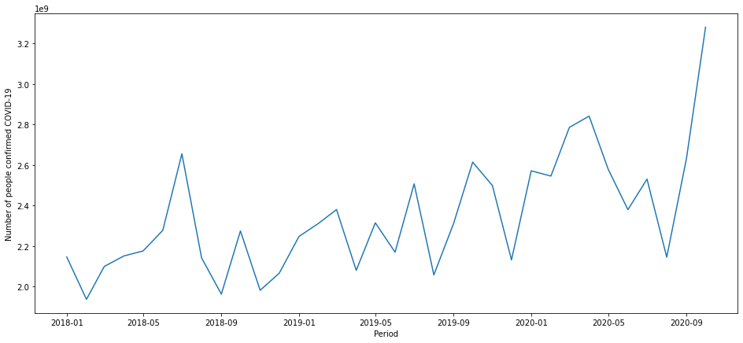

```python
# Data Exploration

plt.figure(figsize=(16,7))
fig = plt.figure(1)
ax1 = fig.add_subplot(111)

ax1.set_xlabel('Period')
ax1.set_ylabel('Number of people confirmed COVID-19')
ax1.plot(data)
```

# Checking Stationarity

- Method 1 - Rolling Statistics
- Method 2 - Dickey Fuller Test

```python
# METHOD 1
#Determining rolling statistics
# WINDOW = 12 -- number of month, if days use 365
rolmean = data.rolling(window=12).mean()
rolstd = data.rolling(window=12).std()

plt.figure(figsize=(16,7))
fig = plt.figure(1)
```

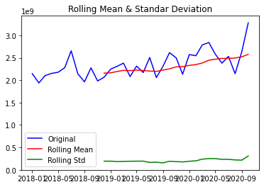

```python
#plot rolling statistics :

orig = plt.plot(data,color='blue',label='Original') #originaldata
mean = plt.plot(rolmean,color='red', label='Rolling Mean')
std = plt.plot(rolstd, color='green',label='Rolling Std')
plt.legend(loc='best')
plt.title('Rolling Mean & Standar Deviation')
plt.show(block=False)
```

We can see from data above

- Rolling standar deviation (green) more or less constant over the time but rolling mean (red) is not constant so we can say this data series in **not stationary**

```python
# METHOD 2
# Perform Dickey-Fuller test
from statsmodels.tsa.stattools import adfuller

print('Results of Dickey-Fuller Test :')
dftest = adfuller(df["EU"], autolag='AIC') #AIC Akaike Info Criteria

dfoutput = pd.Series(dftest[0:4], index=['Test statistics','p-value','#Lags Used','Number of Observation Used'])
for key,value in dftest[4].items():
    dfoutput['Critical Value(%s)'%key] = value

print(dfoutput)
```

```
Results of Dickey-Fuller Test :
Test statistics               -2.455649
p-value                        0.126642
#Lags Used                     0.000000
Number of Observation Used    33.000000
Critical Value(1%)            -3.646135
Critical Value(5%)            -2.954127
Critical Value(10%)           -2.615968
dtype: float64
```

### 0 hipotesis = nonstasionary,

to make it stasionary it should pass these criterias

- p value < 0,05
- critical value should > Test statistic

We can see from data above, we have hight p-value 0.126642 , it's higer than 0.05 Critical value < Test statistic

###### so we can not reject null hypothesis - the data is non statsionary

# MAKING Series Stationary

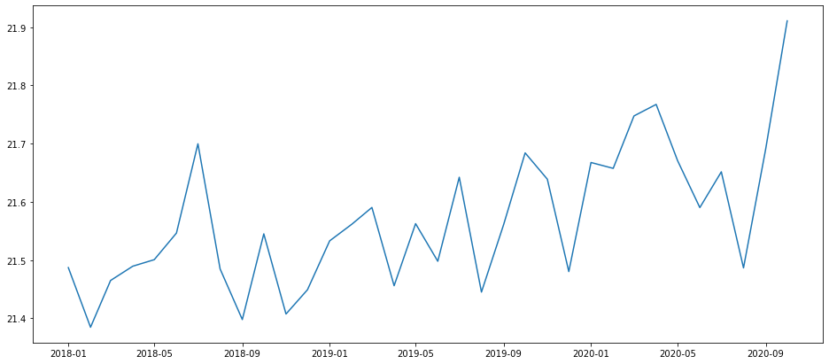

```python
#Let's transform this LOG
plt.figure(figsize=(16,7))
fig = plt.figure(1)

import numpy as np
ts_log = np.log(data)
plt.plot(ts_log)
```

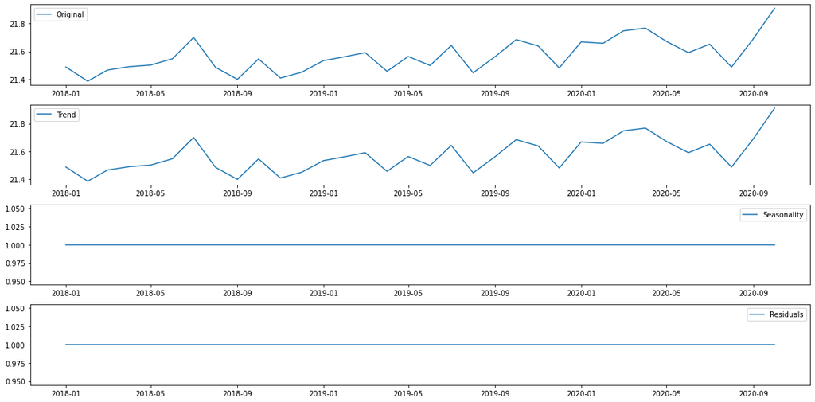

```python
#DECOMPOSITION -- this decomposition will give us difference component of our time series
from statsmodels.tsa.seasonal import seasonal_decompose
decomposition = seasonal_decompose(ts_log,freq=1,model='multiplicative')

trend = decomposition.trend
seasonal = decomposition.seasonal
residual = decomposition.resid

plt.figure(figsize=(16,8))
fig = plt.figure(1)

plt.subplot(411)
plt.plot(ts_log,label ='Original')
plt.legend(loc='best')
plt.subplot(412)
plt.plot(trend,label='Trend')
plt.legend(loc='best')
plt.subplot(413)
plt.plot(seasonal,label ='Seasonality')
plt.legend(loc='best')
plt.subplot(414)
plt.plot(residual,label ='Residuals')
plt.legend(loc='best')
plt.tight_layout()
```

#### From the data above we can see even after log transformation it's still non-stationary

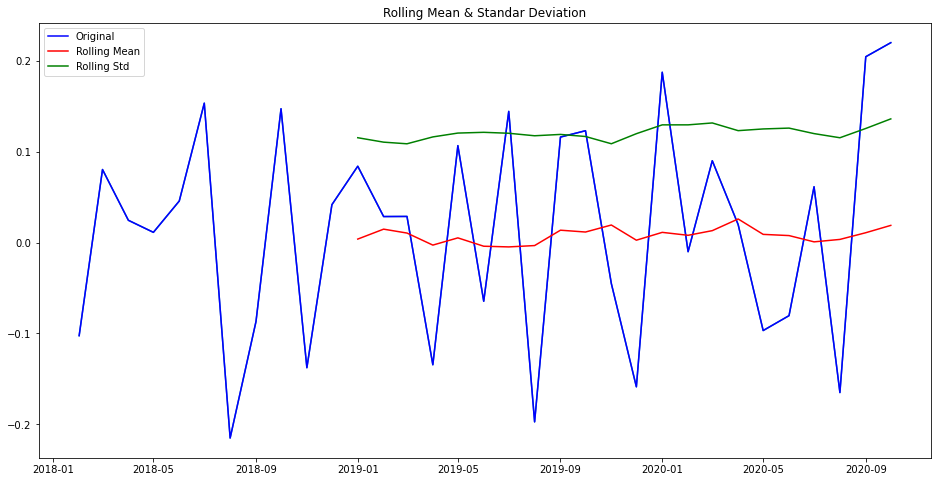

```python
#Let's Try differencing --- we will SHIFT timeseries by 1 and substact timeseries by original series

plt.figure(figsize=(16,8))
fig = plt.figure(1)

ts_log_diff = ts_log - ts_log.shift()
plt.plot(ts_log_diff)

# METHOD 1
#Determining rolling statistics using DIFFERENCE
# WINDOW = 12 -- number of month, if days use 365
rolmean = ts_log_diff.rolling(window=12).mean()
rolstd = ts_log_diff.rolling(window=12).std()


#plot rolling statistics DIFFERENCE :
orig = plt.plot(ts_log_diff,color='blue',label='Original') #originaldata
mean = plt.plot(rolmean,color='red', label='Rolling Mean')
std = plt.plot(rolstd, color='green',label='Rolling Std')
plt.legend(loc='best')
plt.title('Rolling Mean & Standar Deviation')
plt.show(block=False)
```

#### We can see from data above

- Blue - our difference to timeseries
- Rolling standar deviation (green) & rolling mean (red) are now no upward pattern in the mean also in standar deviation. so by the definition of stationarity , if i take mean by these 2 point , there will not be too much difference between these . So I can say/assume now **this time series will be stationary time series**

# ACF AND PACF PLOT

```python
data.sort_index(inplace=True)
```

```python
from statsmodels.tsa.stattools import acf, pacf
lag_acf = acf(ts_log_diff, nlags=10)
lag_pacf = pacf(ts_log_diff, nlags=10)
```

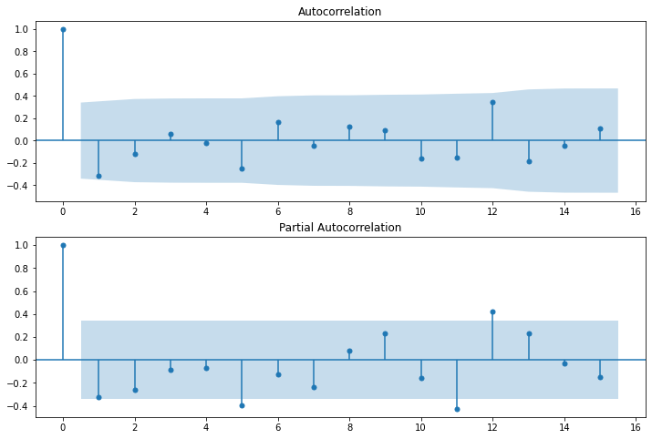

```python
import statsmodels.api as sm
fig = plt.figure(figsize=(12,8))
ax1 = fig.add_subplot(211)
fig = sm.graphics.tsa.plot_acf(ts_log_diff.dropna(),lags=15,ax=ax1) #nlags should be < 50% of sample size our observarion 34 so should be < 16

ax2 = fig.add_subplot(212)
fig = sm.graphics.tsa.plot_pacf(ts_log_diff.dropna(),lags=15,ax=ax2)
```

because we don'nt know the combination we just try

# MAKING ARIMA MODEL

```
Plotting ARIMA model
```

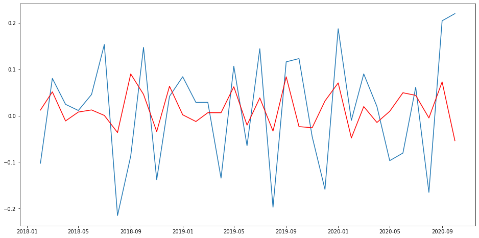

```python
# Import the ARMA model
from statsmodels.tsa.arima_model import ARIMA

plt.figure(figsize=(16,8))
# Instantiate the model ARMA(p=1,d=0,q=1)
model = ARIMA(ts_log, order=(1,1,0))
results_ARIMA = model.fit(disp=-1)


plt.plot(ts_log_diff)
plt.plot(results_ARIMA.fittedvalues, color='red')
print('Plotting ARIMA model')
```

# Taking result to original Scale

```python
ARIMA_diff_predictions = pd.Series(results_ARIMA.fittedvalues,copy=True)
print(ARIMA_diff_predictions.head())
```

```
period
2018-02-01    0.012120
2018-03-01    0.051363
2018-04-01   -0.011253
2018-05-01    0.007878
2018-06-01    0.012423
dtype: float64
```

```python
ARIMA_diff_predictions_cumsum = ARIMA_diff_predictions.cumsum()
print(ARIMA_diff_predictions_cumsum.head())
```

```
period
2018-02-01    0.012120
2018-03-01    0.063483
2018-04-01    0.052231
2018-05-01    0.060109
2018-06-01    0.072532
dtype: float64
```

```python
ARIMA_log_prediction = pd.Series(ts_log.iloc[0],index=ts_log.index)
ARIMA_log_prediction = ARIMA_log_prediction.add(ARIMA_diff_predictions_cumsum,fill_value=0)
ARIMA_log_prediction.head()
```

```
period
2018-01-01    21.487162
2018-02-01    21.499282
2018-03-01    21.550645
2018-04-01    21.539393
2018-05-01    21.547271
dtype: float64
```

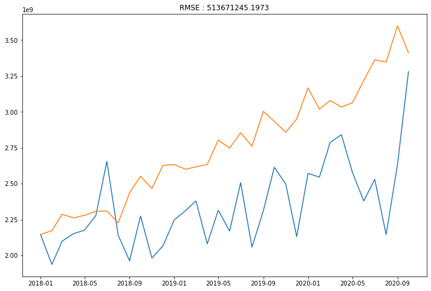

```python
plt.figure(figsize=(12,8))
predictions_ARIMA = np.exp(ARIMA_log_prediction)
plt.plot(data)
plt.plot(predictions_ARIMA)
plt.title('RMSE : %.4f'% np.sqrt(sum((predictions_ARIMA-data)**2)/len(data)))
```

- Blue is original
- Orange is prediction

```python
results_ARIMA.predict(10,20)
```

```
2018-11-01   -0.034161
2018-12-01    0.063448
2019-01-01    0.001995
2019-02-01   -0.012500
2019-03-01    0.006469
2019-04-01    0.006429
2019-05-01    0.062334
2019-06-01   -0.020259
2019-07-01    0.038395
2019-08-01   -0.033167
2019-09-01    0.083855
Freq: MS, dtype: float64
```

```python
!pip install pmdarima
```

[output not shown]

```python
import pmdarima as pm
def arimamodel(timeseries):
    automodel = pm.auto_arima(timeseries,
                             start_p=3,
                             start_q=3,
                             max_p=5,
                             max_q=5,
                             test="adf",
                             seasonal=True,
                             trace=True)
    return automodel
```

```python
arimamodel(ts_log)
```

```
Performing stepwise search to minimize aic
 ARIMA(3,2,3)(0,0,0)[0]             : AIC=-38.145, Time=0.30 sec
 ARIMA(0,2,0)(0,0,0)[0]             : AIC=-12.697, Time=0.02 sec
 ARIMA(1,2,0)(0,0,0)[0]             : AIC=-23.846, Time=0.02 sec
 ARIMA(0,2,1)(0,0,0)[0]             : AIC=inf, Time=0.08 sec
 ARIMA(2,2,3)(0,0,0)[0]             : AIC=-38.697, Time=0.19 sec
 ARIMA(1,2,3)(0,0,0)[0]             : AIC=inf, Time=0.14 sec
 ARIMA(2,2,2)(0,0,0)[0]             : AIC=-40.914, Time=0.14 sec
 ARIMA(1,2,2)(0,0,0)[0]             : AIC=inf, Time=0.08 sec
 ARIMA(2,2,1)(0,0,0)[0]             : AIC=inf, Time=0.11 sec
 ARIMA(3,2,2)(0,0,0)[0]             : AIC=inf, Time=0.15 sec
 ARIMA(1,2,1)(0,0,0)[0]             : AIC=inf, Time=0.06 sec
 ARIMA(3,2,1)(0,0,0)[0]             : AIC=inf, Time=0.10 sec
 ARIMA(2,2,2)(0,0,0)[0] intercept   : AIC=-39.842, Time=0.19 sec

Best model:  ARIMA(2,2,2)(0,0,0)[0]
Total fit time: 1.628 seconds
```

```
ARIMA(order=(2, 2, 2), scoring_args={}, suppress_warnings=True,
      with_intercept=False)
```

### So the best combination showing from arima is 2,2,2

[output not shown]

[output cut: 15 more lines]

[output not shown]

[figure not shown]

```python
# Import the ARMA model
from statsmodels.tsa.arima_model import ARIMA

plt.figure(figsize=(16,8))
# Instantiate the model ARMA(p=2,d=2,q=0)
model = ARIMA(ts_log, order=(2,2,0))
results_ARIMA = model.fit(disp=-1)


plt.plot(ts_log_diff)
plt.plot(results_ARIMA.fittedvalues, color='red')
plt.title('RSS: %.4f'% sum((results_ARIMA.fittedvalues - ts_log_diff["EU"])**2))
print('Plotting ARIMA model')
```

```python
print(results_ARIMA.summary())
```

```
                             ARIMA Model Results
==============================================================================
Dep. Variable:                  D2.EU   No. Observations:                   32
Model:                 ARIMA(2, 2, 0)   Log Likelihood                  17.917
Method:                       css-mle   S.D. of innovations              0.136
Date:                Mon, 01 Feb 2021   AIC                            -27.834
Time:                        11:18:47   BIC                            -21.971
Sample:                    03-01-2018   HQIC                           -25.890
                         - 10-01-2020
===============================================================================
                  coef    std err          z      P>|z|      [0.025      0.975]
-------------------------------------------------------------------------------
const           0.0046      0.010      0.448      0.654      -0.016       0.025
ar.L1.D2.EU    -0.8848      0.159     -5.548      0.000      -1.197      -0.572
ar.L2.D2.EU    -0.5010      0.164     -3.051      0.002      -0.823      -0.179
                                    Roots
=============================================================================
                  Real          Imaginary           Modulus         Frequency
-----------------------------------------------------------------------------
AR.1           -0.8831           -1.1028j            1.4128           -0.3575
AR.2           -0.8831           +1.1028j            1.4128            0.3575
-----------------------------------------------------------------------------
```

```python
predictions_ARIMA_diff = pd.Series(results_ARIMA.fittedvalues,copy=True)
print(predictions_ARIMA_diff.head())
```

```
period
2018-03-01    0.004645
2018-04-01   -0.100339
2018-05-01   -0.031064
2018-06-01    0.050786
2018-07-01   -0.012755
dtype: float64
```

```python
#CONVERT TO CUMULATIVE SUM
predictions_ARIMA_diff_cumsum = predictions_ARIMA_diff.cumsum()
print(predictions_ARIMA_diff_cumsum.head)
```

```
<bound method NDFrame.head of period
2018-03-01    0.004645
2018-04-01   -0.095694
2018-05-01   -0.126757
2018-06-01   -0.075972
2018-07-01   -0.088727
2018-08-01   -0.190140
2018-09-01    0.092918
2018-10-01    0.175118
2018-11-01   -0.085075
2018-12-01    0.060813
2019-01-01    0.055918
2019-02-01   -0.060275
2019-03-01   -0.021403
2019-04-01    0.017309
2019-05-01    0.172691
2019-06-01    0.052236
2019-07-01    0.094022
2019-08-01    0.006068
2019-09-01    0.214698
2019-10-01    0.119695
2019-11-01   -0.032331
2019-12-01    0.124057
2020-01-01    0.319813
2020-02-01    0.081621
2020-03-01    0.094017
2020-04-01    0.115436
2020-05-01    0.138498
2020-06-01    0.287913
2020-07-01    0.342917
2020-08-01    0.220328
2020-09-01    0.360689
2020-10-01    0.158343
dtype: float64>
```

```python
predictions_ARIMA_log = pd.Series(ts_log[1],index=ts_log.index)
predictions_ARIMA_log = predictions_ARIMA_log.add(predictions_ARIMA_diff_cumsum,fill_value=0)
predictions_ARIMA_log.head()
```

```
period
2018-01-01    21.384755
2018-02-01    21.384755
2018-03-01    21.389400
2018-04-01    21.289062
2018-05-01    21.257998
dtype: float64
```

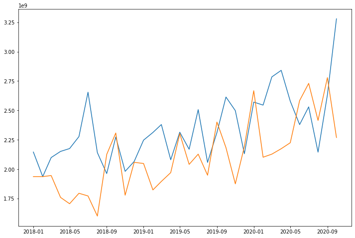

```python
plt.figure(figsize=(12,8))
predictions_ARIMA= np.exp(predictions_ARIMA_log)
plt.plot(data)
plt.plot(predictions_ARIMA)
```

```python
ts_log
```

```
period
2018-01-01    21.487162
2018-02-01    21.384755
2018-03-01    21.465085
2018-04-01    21.489584
2018-05-01    21.500821
2018-06-01    21.546507
2018-07-01    21.699829
2018-08-01    21.484823
2018-09-01    21.397984
2018-10-01    21.545171
2018-11-01    21.407497
2018-12-01    21.449165
2019-01-01    21.533137
2019-02-01    21.561749
2019-03-01    21.590477
2019-04-01    21.456054
2019-05-01    21.562666
2019-06-01    21.498105
2019-07-01    21.642390
2019-08-01    21.445160
2019-09-01    21.561189
2019-10-01    21.684197
2019-11-01    21.639031
2019-12-01    21.480365
2020-01-01    21.667689
2020-02-01    21.657631
2020-03-01    21.747646
2020-04-01    21.767461
2020-05-01    21.670680
2020-06-01    21.590273
2020-07-01    21.651669
2020-08-01    21.486668
2020-09-01    21.691064
2020-10-01    21.910906
Name: EU, dtype: float64
```

```python
# Import libraries
import numpy as np
import pandas as pd
import seaborn as sns
import matplotlib.pyplot as plt
%matplotlib inline
from statsmodels.tsa.arima_model import ARMA
```

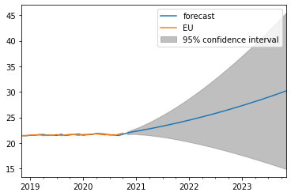

```python
plt.figure(figsize=(25,20))
fig = plt.figure(1)
#result ARIMA ( I want to predict 3 year , 34 + 36 = 70 )
results_ARIMA.plot_predict(10,70)
x=results_ARIMA.forecast(steps=36)
```